# Assignment 2

Student ID: 201903536

31 October 2023

## GitHub

The GitHub repository for **this assignment** can be found [here](https://github.com/emmi3105/472_assignment2). Note that the answer for Exercise 1 can be found in a different GitHub repository, which is linked below.

## Exercise 1

### Task:

Simulate a version control workflow using git and GitHub.

### Answer:

The GitHub repository with the solution for **this exercise** can be found [here](https://github.com/emmi3105/472_assignment2_ex1).

## Exercise 2

### Task:

Generate a ggplot2 visualisation that answers the following question:

“To what extent did different regions of the world implement some form of recommendation or restriction for citizens to stay at home over the course of 2020-2022? How does the introduction of these restrictions compare to the regions’ implementation of income support over the same period?”

#### 1. Read in the data

The data for this task can be found [here](https://github.com/OxCGRT/covid-policy-dataset/blob/main/data/OxCGRT_compact_national_v1.csv). The file is called “OxCGRT_compact_national_v1.csv”.

In order to get a first impression on the contents of the dataset, I printed out the first rows below:

```
## # A tibble: 6 × 56
##   CountryName CountryCode RegionName RegionCode Jurisdiction     Date
##   <chr>       <chr>       <lgl>      <lgl>      <chr>           <dbl>
## 1 Aruba       ABW         NA         NA         NAT_TOTAL    20200101
## 2 Aruba       ABW         NA         NA         NAT_TOTAL    20200102
## 3 Aruba       ABW         NA         NA         NAT_TOTAL    20200103
## 4 Aruba       ABW         NA         NA         NAT_TOTAL    20200104
## 5 Aruba       ABW         NA         NA         NAT_TOTAL    20200105
## 6 Aruba       ABW         NA         NA         NAT_TOTAL    20200106
## # ℹ 50 more variables: `C1M_School closing` <dbl>, C1M_Flag <dbl>,
## #   `C2M_Workplace closing` <dbl>, C2M_Flag <dbl>,
## #   `C3M_Cancel public events` <dbl>, C3M_Flag <dbl>,
## #   `C4M_Restrictions on gatherings` <dbl>, C4M_Flag <dbl>,
## #   `C5M_Close public transport` <dbl>, C5M_Flag <dbl>,
## #   `C6M_Stay at home requirements` <dbl>, C6M_Flag <dbl>,
## #   `C7M_Restrictions on internal movement` <dbl>, C7M_Flag <dbl>, …
```

#### 2. Clean the data

As of now, the dataset includes 56 variables, of which many are not of interest for the visualisation. Furthermore, the “Date” variable is not formatted correctly. Also, the tasks requires me to group the countries into different regions. The dataset does include a variable indicating the country’s region called “RegionName”. However, as seen in the first few rows of the dataset printed out above, the RegionName variable includes missing values, making it impossible to assign all of the observations to a specific region. Additionally, some of the column names such as “C6M_Stay at home requirements” include white space, which might lead to complications as R may not be able to handle these column names when using certain functions and packages.

Therefore, I need to clean the data before I can start with the visualisation. More precisely, I will

- only select the variables that are needed for the plot so that I can decrease the size of the dataset,
- format the date variable correctly so that it has the format Year-month-day,
- assign all observations to regions using the “countrycode” package,
- replace white space in column names,
- drop observations with missing values.

Now, I have a dataset with 202’760 observations and 5 variables. The variables are:

1. “CountryName” indicating the name of the country
2. “RegionName” indicating the name of the region that the country was assigned to above. The seven different regions are printed out below.

```
## [1] "Latin America & Caribbean"  "South Asia"
## [3] "Sub-Saharan Africa"         "Europe & Central Asia"
## [5] "Middle East & North Africa" "East Asia & Pacific"
## [7] "North America"
```

3. “C6M_Stay_at_home_requirements” indicating whether the observation had some sort of stay at home requirement

This variable is categorical and can take the following values:

```
## [1] 0 1 2 3
```

According to the [codebook](https://github.com/OxCGRT/covid-policy-dataset/blob/main/documentation_and_codebook.md) in the GitHub repository, the categories mean the following:

- 0 - no measures
- 1 - recommend not leaving house
- 2 - require not leaving house with exceptions for daily exercise, grocery shopping, and ‘essential’ trips
- 3 - require not leaving house with minimal exceptions (eg allowed to leave once a week, or only one person can leave at a time, etc)
- Blank - no data

Note that this variable is **ordinal**.

4. “E1_Income_support” indicating whether the observation received some sort of income support

Similarly to the stay at home requirement, this variable is also categorical and can take the following values:

```
## [1] 0 2 1
```

According to the [codebook](https://github.com/OxCGRT/covid-policy-dataset/blob/main/documentation_and_codebook.md), the categories mean the following:

- 0 - no income support
- 1 - government is replacing less than 50% of lost salary (or if a flat sum, it is less than 50% median salary)
- 2 - government is replacing 50% or more of lost salary (or if a flat sum, it is greater than 50% median salary)
- Blank - no data

Note that this variable is **ordinal** as well.

5. “Date” indicating the date in a Year-month-day format

#### 3. Prepare the data for plotting

We have cleaned and filtered the data for the variables of interest. However, the two variables indicating the stay at home requirements and the income support cannot be plotted as they are. The reason for that lies in the fact that the variables are categorical - meaning that the values represent different categories - and ordinal - meaning that the distance between two different categories is not known and thereby not meaningful in a quantitative way. If we were to plot ordinal variables without any transformation, the visualisation would be misleading as it would seem as if the difference between two different holds some sort of quantitative information, although the difference itself is arbitrary. Hence, I will create binary variables that merely indicate whether there has been some sort of stay-at-home requirement or income support respectively thereby getting rid of other categories and the ordinal scale.

The new variable “restriction_binary” takes a value of 1 if there has been some sort of stay at home restriction and 0 if no requirements at all have been enforced. The new variable “income_binary” takes a value of 1 if the government has granted some sort of income support and 0 if no income support at all has been installed.

Lastly, I need to create a new variable indicating the percentage of the observations for each region for which the binary variables above are 1. The reason for this step lies in the fact that I need to summarise the values of the binary variables from all countries of one and the same region into one. As the binary variable itself can only take the two values 0 and 1, it makes sense to use the percentage of countries that have installed the requested policies as the variable that should be plotted. I create these two percentage variables by firstly grouping the data by region and then calculating the average for the restriction and income binaries by applying mutate() to the grouped data.

#### 4. Visualisation

Below, the plot showing the implementation of stay-at-home policies and income support in seven different global regions over the course of 2020-2022 was printed out. It consists of seven facets rerpesenting one global region each. The x-axis shows the “Date” variable, which holds the time between the beginning of 2020 and the end of 2022. The y-axis shows the percentage of countries from one region. The solid blue line plots how many countries from one region (in percent) implemented stay-at-home policies at each point of time. The dashed pink line demonstrates how many countries from one region (in percent) installed income support at each point of time. Further explanations of and the reasoning behind this visualisation can be found in the paragraph below the graph.

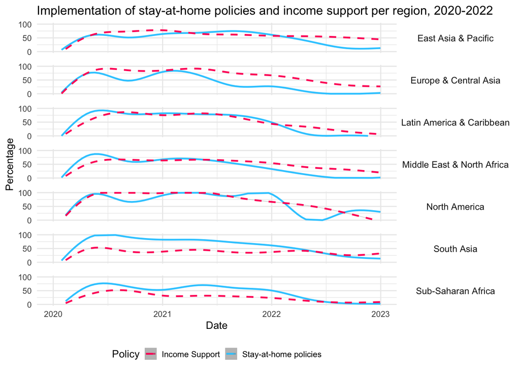

#### 5. Discussion of the visualisation

The visualisation above shows the percentage of countries in one region that have implemented stay-at-home requirements and income support over the course of 2020-2022. This graph was chosen as it allows to analyse three elements:

1. Firstly, it allows to **compare the implementations of stay-at-home requirements to the implementation of income support in one region**. For example, we can deduct that around May/June 2022, no countries in North America had implemented stay-at-home requirements, yet around 50% of North American countries granted income support of some sort.
2. Secondly, the graph enables a **comparison of policies across different regions**. For example, we can see that around May/June 2022, North American countries had no policies requiring the people to stay at home. Yet, at the same time, around 30% - 40% of countries in the region East Asia & Pacific had some sort of stay-at-home requirements.
3. Lastly, the graph models the **change of stay-at-home and income support policies across the time of 2020-2022**. For instance, we can see that stay-at-home policies started to become more prominent around May 2020 across most regions, which intuitively makes sense as the number of Covid cases started to pick up during this time globally (for more information on Covid cases across the different regions, refer to the [World Health organisation](https://covid19.who.int/)).

In the table below, it is summarised why certain graph features were chosen to enable the analysis of the three elements listed above.

[output not shown]

## Exercise 3

### Task 1:

Write three functions that transform strings according to three different patterns using regular expressions.

#### Transformation a

Transformation pattern: “apple” -> “pple” | “abacus” -> “bacus” | “Annapolis” -> “nnapolis”

I need to write a function that deletes the first character of the input string. Note that the function must be executable on lowercase strings as well as uppercase strings.

```r
#####################################
# EXERCISE 3 - Part 1
#####################################
# A
#####################################

# Write a function that deletes the first character of a string
# using a regular expression

function_a <- function(astring) {
  # Deletes the first character of a string
  #
  # Inputs
  # astring: a string variable
  #
  # Output
  # returns the string without the first character

  new_string_a <- sub("^.([a-z])", "\\1", astring, ignore.case = TRUE)
  return(new_string_a)
}

# Test the function on the example strings
function_a("apple")
```

```
## [1] "pple"
```

```r
function_a("abacus")
```

```
## [1] "bacus"
```

```r
function_a("Annapolis")
```

```
## [1] "nnapolis"
```

```r
# Test the function on my own example string
function_a("Apfelmark")
```

```
## [1] "pfelmark"
```

#### Transformation b

Transformation pattern: “apple” -> “pple” | “abacus” -> “bcus” | “Annapolis” -> “Annpolis”

I need to write a function that deletes all lowercase “a” characters of the input string. Note that this time, the function should differentiate between lowercase and uppercase letters.

```r
#####################################
# B
#####################################

# Write a function that deletes all "a"s of a string
# that are lowercase using a regular expression

function_b <- function(astring) {
  # Deletes the all lowercase "a" characters of a string
  #
  # Inputs
  # astring: a string variable
  #
  # Output
  # returns the string without all lowercase "a"s

  new_string_b <- gsub("a", "", astring, ignore.case = FALSE)
  return(new_string_b)
}

# Test the function on the example strings
function_b("apple")
```

```
## [1] "pple"
```

```r
function_b("abacus")
```

```
## [1] "bcus"
```

```r
function_b("Annapolis")
```

```
## [1] "Annpolis"
```

```r
# Test the function on my own example string
function_b("Apfelmark")
```

```
## [1] "Apfelmrk"
```

#### Transformation c

Transformation pattern: “C1_nat_a” -> “C_a” | “D2_state_g” -> “D_g” | “E_Loc_5_i” -> “E_i”

We need a function that returns the first character as well as the last two characters of the string. Note that in this particular exercise, the same result can be achieved in multiple ways. For instance, we could alternatively write a function that keeps the first and the last character of a string and separates them with an underscore. However, we will follow the first option.

```r
#####################################
# C
#####################################

# Write a function that returns the first character and the last two characters
# of a string using a regular expression

function_c <- function(astring) {
  # Deletes all characters but the first character and the last two characters of a string
  #
  # Inputs
  # astring: a string variable
  #
  # Output
  # returns the first character and the last two characters

  new_string_c <- sub("^(.).*(..)$", "\\1\\2", astring, ignore.case = TRUE)
  return(new_string_c)
}

# Test the function on the example strings
function_c("C1_nat_a")
```

```
## [1] "C_a"
```

```r
function_c("D2_state_g")
```

```
## [1] "D_g"
```

```r
function_c("E_Loc_5_i")
```

```
## [1] "E_i"
```

```r
# Test the function on my own example string
function_c("F3_city_l")
```

```
## [1] "F_l"
```

### Task 2:

Develop a research question that can be answered by counting how often certain words were mentioned in two books extracted from the [Gutenberg Project](https://www.gutenberg.org/) using a dictionary of words.

#### 1. Research question

For this task, the following research question should be answered:

**Which fairy tale figures are the most prominent ones in German compared to English fairy tales?**

In order to answer this question, two collections of fairy tales are downloaded from the Gutenberg Project:

1. [Grimms’ fairy tales (German)](https://www.gutenberg.org/ebooks/2591)
2. [English fairy tales](https://gutenberg.org/ebooks/7439)

I used ChatGPT [1] to configure ten different types of popular fairy tale figures and came up with the following list:

- Dragon
- Dwarf
- Elf
- Fairy
- Giant
- Prince
- Princess
- Troll
- Witch
- Wizard

I can now count the number of times these ten fairy tale figures were mentioned in the collections of German and English fairy tales in order to compare whether the two countries potentially have preferences for different fairy tale figures.

#### 2. Select and download the books

Firstly, I downloaded the two fairy tale collections mentioned above as .txt files and read them into R. The code chunk for this step can be seen in the Appendix.

#### 3. Build a corpus from the two books

Then, I created a `corpus` object from the two texts using the `quanteda` package. This allowed me to not only store the content of the two books but to also store the names of each book under a so called document variable (`docvars`). I also stored the number of characters as document variables as the varying length of the two texts might explain why one book potentially holds more overall mentions of fairy tale figures than the other. The `docvars` are printed out below.

```
##                  name characters
## 1 Grimms' Fairy Tales     540088
## 2 English Fairy Tales     342944
```

As we can see above, the English fairy tale book is significantly shorter than the German one. Hence, we could expect that the mentions of fairy tale figures is generally higher in “Grimms’ Fairy Tales”. Let’s find out whether these expectations are met.

#### 4. Build a dictionary and use it to count the mentions of fairy tale creaturs

Based on ChatGPT’s suggestions, I built a dictionary holding ten prevalent types of fairy tale creatures. For each figure, I made the simplification of only considering the noun in its singular and plural form and neglecting other forms using pre- or suffixes. Furthermore I ignored that the fairy tale figures could also be a part of a different word not refferring to the figure itself, such as “fairy” in the word “fairy tale”. The dictionary is printed out below.

```
## Dictionary object with 10 key entries.
## - [dragon]:
##   - dragon, dragons
## - [dwarf]:
##   - dwarf, dwarfs, dwarves
## - [elf]:
##   - elf, elves
## - [fairy]:
##   - fairy, faries
## - [giant]:
##   - giant, giants
## - [prince]:
##   - prince, princes
## [ reached max_nkey ... 4 more keys ]
```

Using the `tokens()` function and the corpus created in the previous step, I create a document-feature matrix (dfm). The rows of the dfm represent each of the two books and the columns show all words included in the books. The cells show the word counts in the respective book.

The dfm can now be used to count the mentions of the different fairy tale figures. Using the function dfm_lookup(), I check how many times the words in the dictionary were mentioned in the two books. The results are printed out below.

```
## Document-feature matrix of: 2 documents, 10 features (15.00% sparse) and 2 docvars.
##                      features
## docs                  dragon dwarf elf fairy giant prince princess troll witch
##   Grimms' Fairy Tales     14    77   4    27    47     73      120     0    31
##   English Fairy Tales      3     2   4    43    93     46       13     6     4
##                      features
## docs                  wizard
##   Grimms' Fairy Tales      0
##   English Fairy Tales      0
```

#### 5. Discussion of the findings

As seen in the results printed out above, there are quite large differences between the times that different creatures have been mentioned in the two fairy tale books. Not only do the creatures seem to vary in popularity within one book - as for instance seen in comparing the mentions of princesses versus the mentions of trolls in “Grimms’ Fairy Tales” - but the two books seem to have different preferences for fairy tale figures. In German fairy tales, princesses, princes and dwarfs are the most prominent figures, whilst English books on the contrary seem to have a strong preference for giants, princes and fairies. In the ggplot below, these findings are visualised.

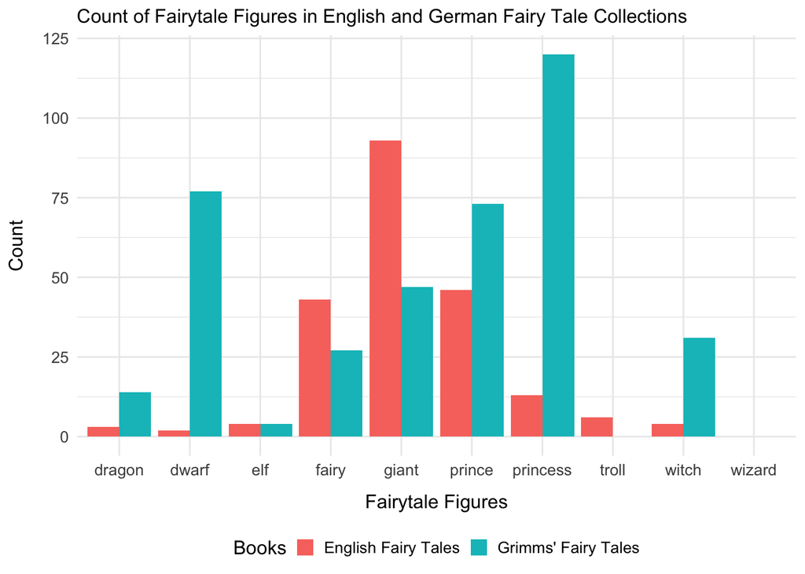

Lastly, it should be stressed that my basic analysis of the popularity of fairytale creatures is flawed. Firstly, there are mistakes in counting the instances, such as the neglection of the word “fairy” in the context of the story type “fairy tale” rather than the figure of a fairy itself. Secondly, it should be noted that the Grimm stories were translated from German into English, which might have led to faulty translations. For instance, the word “Zauberer” could be translated as “wizard” but also as “sorcerer” or some other synonymous word. Potentially, the absence of wizards in the German fairy tale collection could be caused by faulty translations and not because German fairy tales do not include the figure of a wizard at all. Furthermore, neither the dictionary nor the book examples are finite lists making it impossible to formulate generalising conclusions on the preferences for some fairy tale figures over others in different countries.

## Data

[1] Horst, A., Hill, A., and Gorman, K. (2020). “palmerpenguins: Palmer Archipelago (Antarctica) penguin data.” R package version 0.1.0. https://allisonhorst.github.io/palmerpenguins/. doi: 10.5281/zenodo.3960218.

[2] Hale, T., Angrist, N., Goldszmidt, R., Kira, B., Petherick, A., Phillips, T., Webster, S., Cameron-Blake, E., Hallas, L., Majumdar, S., and Tatlow, H. (2021). “A global panel database of pandemic policies (Oxford COVID-19 Government Response Tracker).” Nature Human Behaviour. doi: 10.1038/s41562-021-01079-8

[3a] Grimm, J. and Grimm, W. (Uploaded 2001). “Grimms’ Fairy Tales.” Project Gutenberg. Retrieved from https://www.gutenberg.org/ebooks/2591

[3b] Jacobs, J. (Uploaded 2005). “English Fairy Tales.” Project Gutenberg. Retrieved from https://gutenberg.org/ebooks/7439

## Sources

[1] [ChatGPT](https://chat.openai.com/): Generate a list of prominent fairy tale figures

[2] [R Documentation](https://www.rdocumentation.org/packages/reshape2/versions/1.4.4/topics/melt.data.frame): melt function

## Appendix: All code in this assignment

```r
#####################################
# SETUP
#####################################

knitr::opts_chunk$set(echo = FALSE)

#####################################
# Install/load packages
#####################################

library(readr)
library(tidyverse)
library(countrycode)
library(quanteda)
library(quanteda.textplots)
library(ggplot2)
library(reshape2)


#####################################
# EXERCISE 2
#####################################
# Read in the data
#####################################

# Read in the data from GitHub and save it as cov_data
urlfile = "https://raw.githubusercontent.com/OxCGRT/covid-policy-dataset/main/data/OxCGRT_compact_national_v1.csv"
cov_data <- read_csv(url(urlfile))

# Print the first rows of the dataset
print(head(cov_data))


#####################################
# Clean the data
#####################################

data_clean <- cov_data %>%
  # Select the variables of interest
  select(matches(c("CountryName",
                   "RegionName",
                   "C6M_Stay at home requirements",
                   "E1_Income support",
                   "Date"))) %>%
  # Format the date variable to Year-month-day
  mutate(Date = as.character(Date),
         Date = ymd(Date)) %>%
  # Add region names using the countrycode package
  mutate(RegionName = countrycode(CountryName, "country.name", "region")) %>%
  # Replace white space in column names with underscores
  rename_all(~gsub("\\s", "_", .)) %>%
  # Drop missing values
  drop_na()

# Print the unique values of the region name variable
print(unique(data_clean$RegionName))

# Check the values of the stay at home requirements variable
print(unique(data_clean$C6M_Stay_at_home_requirements))

# Check the values of the income support variable
print(unique(data_clean$E1_Income_support))


#####################################
# Prepare the data for plotting
#####################################

# Create a binary variable indicating stay at home restrictions
data_clean$restriction_binary <- ifelse(data_clean$C6M_Stay_at_home_requirements == 1 | data_clean$C6M_Stay_at_home_requirements == 2 | data_clean$C6M_Stay_at_home_requirements == 3, 1, 0)

# Create a binary variable indicating income support
data_clean$income_binary <- ifelse(data_clean$E1_Income_support == 1 | data_clean$E1_Income_support == 2, 1, 0)

# Group the dataframe and calculate the percentage
plot_data <- data_clean %>%
  group_by(RegionName, Date) %>%
  mutate(restriction_percentage = mean(restriction_binary) * 100) %>%
  mutate(income_percentage = mean(income_binary) * 100) %>%
  drop_na() %>%
  ungroup()


#####################################
# Create the visualisation
#####################################

my_plot <- ggplot(plot_data, aes(x = Date, group = RegionName)) +
  # Add a smooth line for the stay at home requirement percentage
  geom_smooth(aes(y = restriction_percentage, color = "Restriction"),
              linetype = "solid", linewidth = 0.8) +
  # Add a smooth line for the income support percentag
  geom_smooth(aes(y = income_percentage, color = "Income"),
              linetype = "dashed", linewidth = 0.8) +
  # Add a title and axes labels
  labs(title = "Implementation of stay-at-home policies and income support per region, 2020-2022",
       x = "Date",
       y = "Percentage") +
  # Set colors for the two binary variables and add a legend
  scale_color_manual(name = "Policy", values = c("#ff0066", "#33CCFF"),
                     labels = c("Income Support", "Stay-at-home policies")) +
  # Add further elements such as the text size, line width, etc.
  theme_minimal() +
  scale_y_continuous(limits = c(0, 100), breaks = c(0, 50, 100)) +
  theme(plot.title = element_text(size = 12),
        axis.title = element_text(size = 10),
        axis.text = element_text(size = 8),
        legend.title = element_text(size = 10),
        legend.text = element_text(size = 8),
        legend.position = "bottom",
        strip.text.y = element_text(angle = 0),
        panel.spacing = unit(0.8, "lines"),
        legend.key.size = unit(0.8, "lines"))

# Adjust width and height as needed
options(repr.plot.width = 12, repr.plot.height = 8)

# Add facets to the plot so that each region is represented in one facet
final_plot <- my_plot + facet_grid(rows = vars(RegionName))

# Print out the final plot
print(final_plot)


#####################################
# EXERCISE 3 - Part 1
#####################################
# A
#####################################

# Write a function that deletes the first character of a string
# using a regular expression

function_a <- function(astring) {
  # Deletes the first character of a string
  #
  # Inputs
  # astring: a string variable
  #
  # Output
  # returns the string without the first character

  new_string_a <- sub("^.([a-z])", "\\1", astring, ignore.case = TRUE)
  return(new_string_a)
}

# Test the function on the example strings
function_a("apple")
function_a("abacus")
function_a("Annapolis")

# Test the function on my own example string
function_a("Apfelmark")


#####################################
# B
#####################################

# Write a function that deletes all "a"s of a string
# that are lowercase using a regular expression

function_b <- function(astring) {
  # Deletes the all lowercase "a" characters of a string
  #
  # Inputs
  # astring: a string variable
  #
  # Output
  # returns the string without all lowercase "a"s

  new_string_b <- gsub("a", "", astring, ignore.case = FALSE)
  return(new_string_b)
}

# Test the function on the example strings
function_b("apple")
function_b("abacus")
function_b("Annapolis")

# Test the function on my own example string
function_b("Apfelmark")


#####################################
# C
#####################################

# Write a function that returns the first character and the last two characters
# of a string using a regular expression

function_c <- function(astring) {
  # Deletes all characters but the first character and the last two characters of a string
  #
  # Inputs
  # astring: a string variable
  #
  # Output
  # returns the first character and the last two characters

  new_string_c <- sub("^(.).*(..)$", "\\1\\2", astring, ignore.case = TRUE)
  return(new_string_c)
}

# Test the function on the example strings
function_c("C1_nat_a")
function_c("D2_state_g")
function_c("E_Loc_5_i")

# Test the function on my own example string
function_c("F3_city_l")


#####################################
# EXERCISE 3 - Part 2
#####################################

# Read the texts from the files
grimm_book <- read_file("grimm_fairy_tales.txt")
english_book <- read_file("english_fairy_tales.txt")

fairy_documents <- c(grimm_book, english_book)
names(fairy_documents) <- c("Grimms' Fairy Tales", "English Fairy Tales")

# Create a corpus
fairy_corpus <- corpus(fairy_documents,
                           docvars = data.frame(name = names(fairy_documents),
                                                characters = str_count(fairy_documents))
                           )

# Print out the document variables
docvars(fairy_corpus)

# Create a dictionary based on ChatGPT fairy tale creature suggestions
fairy_dict <- dictionary(list(dragon = c("dragon", "dragons"),
                              dwarf = c("dwarf", "dwarfs", "dwarves"),
                              elf = c("elf", "elves"),
                              fairy = c("fairy", "faries"),
                              giant = c("giant", "giants"),
                              prince = c("prince", "princes"),
                              princess = c("princess", "princesses"),
                              troll = c("troll", "trolls"),
                              witch = c("witch", "witches"),
                              wizard = c("wizard", "wizards")
                               ))
fairy_dict

# Convert the corpus to tokens
fairy_tokens <- tokens(fairy_corpus)

# Convert the tokens to a document-feature matrix (dfm)
fairy_dfm <- dfm(fairy_tokens)

dfm_dictionary <- dfm_lookup(fairy_dfm, dictionary = fairy_dict,
                               valuetype = "glob")
dfm_dictionary

# Convert the dfm to a dataframe
df <- convert(dfm_dictionary, to = "data.frame")

# Melt the dataframe for better visualization
# Source: https://www.rdocumentation.org/packages/reshape2/versions/1.4.4/topics/melt.data.frame [2]
df_melted <- melt(df, id.vars = "doc_id")

# Create the ggplot
ggplot(df_melted, aes(x = variable, y = value, fill = doc_id)) +
  geom_bar(stat = "identity", position = "dodge") +
  # Add a title and axes labels
  labs(title = "Count of Fairytale Figures in English and German Fairy Tale Collections",
       x = "Fairytale Figures",
       y = "Count",
       fill = "Books") +
  theme_minimal() +
  scale_color_manual(name = "Book", values = c("#ff0066", "#33CCFF"),
                     labels = c("English Fairy Tales", "Grimms' Fairy Tales")) +
  theme(plot.title = element_text(size = 12),
      axis.title = element_text(size = 12),
      axis.text = element_text(size = 10),
      legend.title = element_text(size = 12),
      legend.text = element_text(size = 10),
      legend.position = "bottom",
      legend.key.size = unit(0.8, "lines")) +
  theme(axis.title.x = element_text(margin = margin(t = 10)),
        axis.title.y = element_text(margin = margin(r = 10)))
```